# Awards Testing

2024-10-31

reading in the dataset

This visualization provides a clear bar chart illustrating the distribution of award types within our dataset, highlighting the count of each award. I don’t think this is the best way to visualise distribution of each award more so because it causes the audience to have to turn their head. Wouldnt bee good in a stakeholder meeting.

[figure not shown]

```r
library(ggplot2)
ggplot(awards, aes(x = Award)) +
  geom_bar(fill = "blue") +
  labs(title = "Count of Each Award Type", x = "Award Type", y = "Count") +
  theme(axis.text.x = element_text(angle = 90, hjust = 1))
```

This bar chart illustrates the number of winners over the years, segmented by the winning status, with different colors representing winners and non-winners. Reeadability is a bit low with how the years are jumbled together.

[figure not shown]

```r
library(dplyr)
top_winners <- awards %>%
  filter(Winner == 1) %>%
  count(Name, sort = TRUE) %>%
  top_n(10)
```

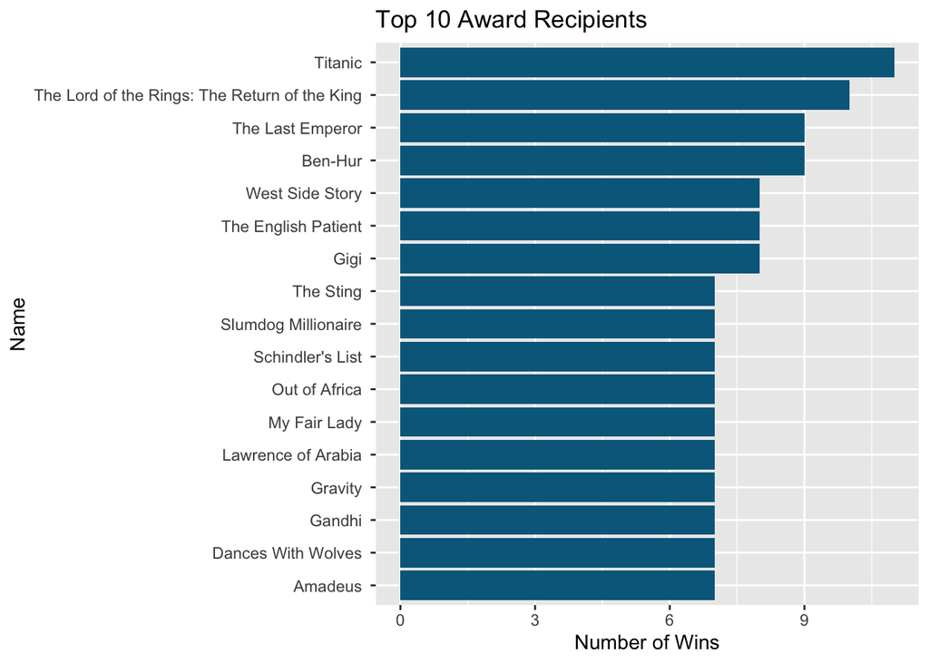

```r
ggplot(top_winners, aes(x = reorder(Name, n), y = n)) +
  geom_bar(stat = "identity", fill = "deepskyblue4") +
  labs(title = "Top 10 Award Recipients", x = "Name", y = "Number of Wins") +
  coord_flip()
```

This histogram visualizes the distribution of awards over the years, with the x-axis representing the years and the y-axis indicating the count of awards for each year. The chart effectively highlights trends in award distributions, allowing stakeholders to quickly assess the frequency of awards given across different years in a clean and minimalistic format. I would be more mindful of bin width sensitivity if I was going to display data like this. Sometimes it might be hard to interpret.

```r
awards$Year = as.numeric(awards$Year)
```

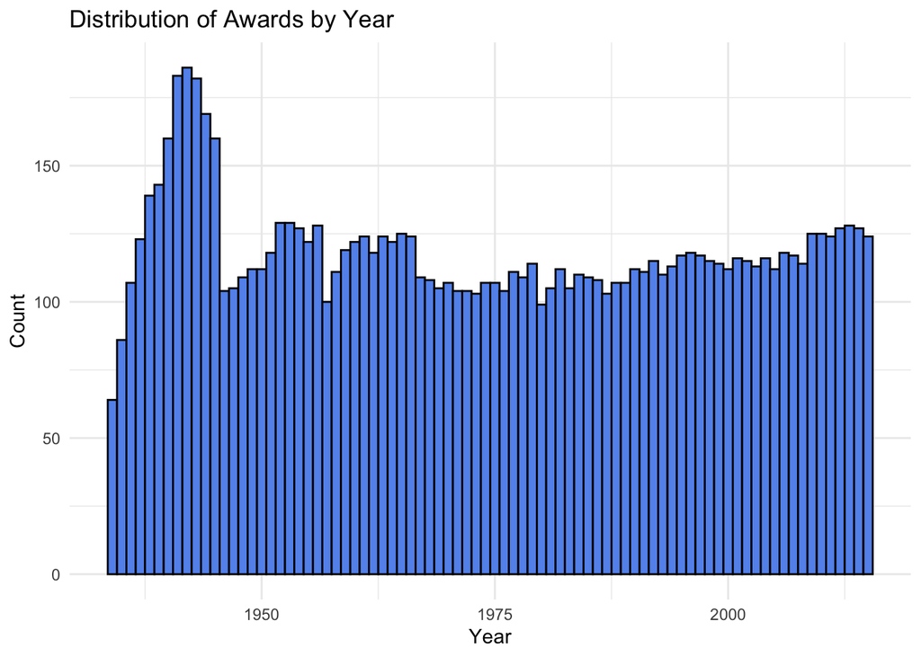

```r
library(ggplot2)
ggplot(awards, aes(x = Year)) +
  geom_histogram(binwidth = 1, fill = "cornflowerblue", color = "black") +
  labs(title = "Distribution of Awards by Year", x = "Year", y = "Count") +
  theme_minimal()
```

I don’t like this one. This visualization displays the proportion of winners for each award type, with the x-axis representing different award types and the y-axis showing the percentage of winners. The chart doesn’t give enough context for us to fully interpret this data. Good experiment but wouldn’t use this one.

[figure not shown]

```r
awards %>%
  group_by(Award) %>%
  summarise(winner_percentage = mean(Winner == 1, na.rm = TRUE)) %>%
  ggplot(aes(x = reorder(Award, winner_percentage), y = winner_percentage)) +
  geom_col(fill = "brown") +
  coord_flip() +
  labs(title = "Proportion of Winners by Award Type", x = "Award Type", y = "Winner Percentage") +
  theme_minimal()
```

```r
top_films = awards %>%
  filter(Winner == 1) %>%
  count(Film, sort = TRUE) %>%
  top_n(10)
```

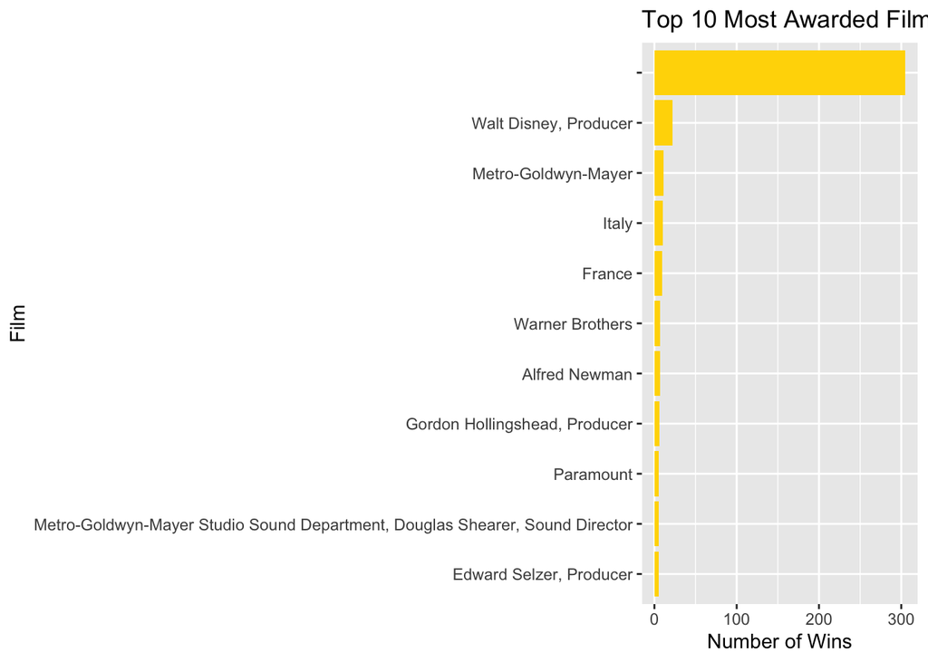

```r
ggplot(top_films, aes(x = reorder(Film, n), y = n)) +
  geom_bar(stat = "identity", fill = "gold") +
  coord_flip() +
  labs(title = "Top 10 Most Awarded Films", x = "Film", y = "Number of Wins")
```

I dont know where I went wrong here, but I wouldn’t use this at all.

[figure not shown]

```r
awards = awards %>% filter(!is.na(Year))
awards %>%
  group_by(Year, Award) %>%
  summarise(count = n()) %>%
  ggplot(aes(x = Year, y = count, color = Award)) +
  geom_line() +
  labs(title = "Number of Awards by Category Over Time", x = "Year", y = "Count") +
  theme_minimal()
```

This stacked bar chart illustrates the distribution of winners versus nominees over the years, with the x-axis representing the years and the y-axis showing the proportion of each category. Big downfall here is the chart shows proportions, it does not convey the actual counts of winners and nominees, which can be important for understanding the overall context of the data.

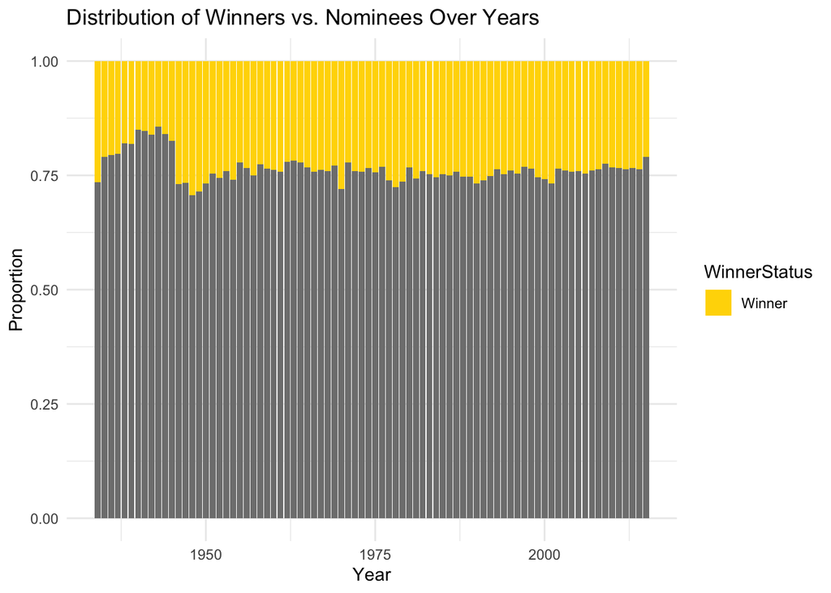

```r
awards %>%
  mutate(WinnerStatus = ifelse(Winner == 1, "Winner", "Nominee")) %>%
  ggplot(aes(x = Year, fill = WinnerStatus)) +
  geom_bar(position = "fill") +
  labs(title = "Distribution of Winners vs. Nominees Over Years", x = "Year", y = "Proportion") +
  scale_fill_manual(values = c("Nominee" = "lightgrey", "Winner" = "gold")) +
  theme_minimal()
```

```r
top_names = awards %>%
  filter(Winner == 1) %>%
  count(Name, sort = TRUE) %>%
  top_n(5) %>%
  pull(Name)
```

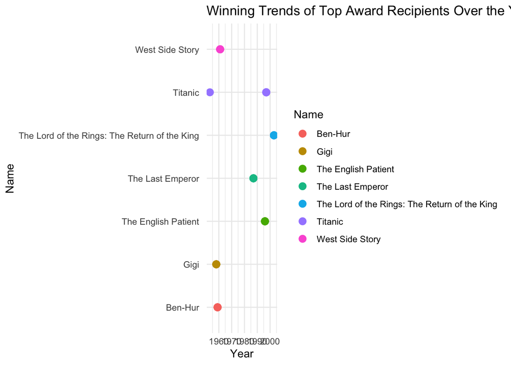

```r
awards %>%
  filter(Name %in% top_names & Winner == 1) %>%
  ggplot(aes(x = Year, y = Name, color = Name)) +
  geom_point(size = 3) +
  labs(title = "Winning Trends of Top Award Recipients Over the Years", x = "Year", y = "Name") +
  theme_minimal()
```

Easy to interpret but not one of my strongest graph.

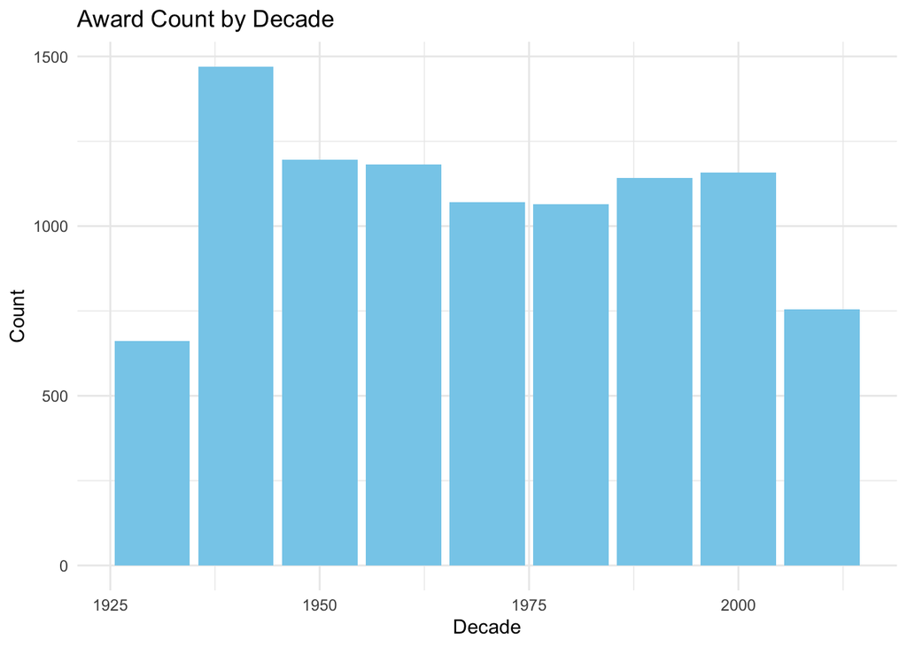

```r
awards %>%
  mutate(Decade = floor(Year / 10) * 10) %>%
  group_by(Decade) %>%
  summarise(count = n()) %>%
  ggplot(aes(x = Decade, y = count)) +
  geom_bar(stat = "identity", fill = "skyblue") +
  labs(title = "Award Count by Decade", x = "Decade", y = "Count") +
  theme_minimal()
```

```r
library(dplyr)
awards = awards %>%
  filter(!is.na(Winner) & !is.na(Year) & !is.na(Ceremony))
library(dplyr)
library(randomForest)
print(sum(is.na(awards$Winner)))
```

```
## [1] 0
```

```r
print(sum(is.na(awards$Year)))
```

```
## [1] 0
```

```r
print(sum(is.na(awards$Ceremony)))
```

```
## [1] 0
```

```r
awards = awards %>%
  filter(!is.na(Winner) & !is.na(Year) & !is.na(Ceremony))
```

randomforest is not the best model to run here for predicting the Winner variable.

```r
rf_model = randomForest(Winner ~ Year + Ceremony, data = awards)
print(rf_model)
```

```
##
## Call:
##  randomForest(formula = Winner ~ Year + Ceremony, data = awards)
##                Type of random forest: regression
##                      Number of trees: 500
## No. of variables tried at each split: 1
##
##           Mean of squared residuals: 0
##                     % Var explained: NaN
```

```r
awards$rf_predicted_winner = predict(rf_model, awards)
head(awards[, c("Year", "Winner", "rf_predicted_winner")])
```

```
##   Year Winner rf_predicted_winner
## 1 1934      1                   1
## 2 1934      1                   1
## 3 1934      1                   1
## 4 1934      1                   1
## 5 1934      1                   1
## 6 1934      1                   1
```

With so many categories in year and even ceremony, maybe this model is a little too simple for this dataset.

```r
model_logistic = glm(Winner ~ Year + Ceremony, family = binomial, data = awards)
summary(model_logistic)
```

```
##
## Call:
## glm(formula = Winner ~ Year + Ceremony, family = binomial, data = awards)
##
## Deviance Residuals:
##       Min         1Q     Median         3Q        Max
## 2.409e-06  2.409e-06  2.409e-06  2.409e-06  2.409e-06
##
## Coefficients: (1 not defined because of singularities)
##               Estimate Std. Error z value Pr(>|z|)
## (Intercept)  2.657e+01  6.302e+05       0        1
## Year        -5.928e-08  3.191e+02       0        1
## Ceremony            NA         NA      NA       NA
##
## (Dispersion parameter for binomial family taken to be 1)
##
##     Null deviance: 0.0000e+00  on 2248  degrees of freedom
## Residual deviance: 1.3048e-08  on 2247  degrees of freedom
## AIC: 4
##
## Number of Fisher Scoring iterations: 25
```

```r
library(xgboost)
dtrain = xgb.DMatrix(data = model.matrix(Winner ~ Year + Ceremony, data = awards), label = awards$Winner)
model_xgb = xgboost(dtrain, max_depth = 3, eta = 0.1, nrounds = 200, objective = "binary:logistic")
```